# Class 6: Politically Violent Activity

Leadership

[Dr. Michael C. Zeller](https://michaelzeller.de)

# Opening notes

[Open Sticker](https://tenor.com/view/open-gif-14209777)from [Open Stickers](https://tenor.com/search/open-stickers)

## Presentation groups

Presentations line-up

| Date | Presenters | Method |
| --- | --- | --- |
| 4 Dec: | Shahadaan, Kristine, Daichi | ethnography |
| 11 Dec: | Bérénice, Zorka, Victoria, Katharina | TBD |
| 18 Dec: | Shoam, Aidan, Tara, Sebastian | QCA |

# Leadership

- theories of leadership
  - Weber
  - Nepstad and Bob (2006)
  - Earl (2007)
- an example from far-right movements

[Danny Zuko Grease GIF](https://tenor.com/view/danny-zuko-grease-leader-danny-zuko-leader-grease-leader-gif-26920475)from [Danny Zuko GIFs](https://tenor.com/search/danny+zuko-gifs)

## Theories of leadership

- Max Weber (1922): three ideal types: **legal**, **traditional**, **charismatic**
  - shifting denotation of ‘charisma’ (away from divinity)
    - McDonnell (2016): ‘unique qualities, the unconditional acceptance of authority, and strong emotional attachment to leadership.’
  - examples from this framework?

## Theories of leadership

- Max Weber (1922): three ideal types: **legal**, **traditional**, **charismatic**
  - shifting denotation of ‘charisma’ (away from divinity)
    - McDonnell (2016): ‘unique qualities, the unconditional acceptance of authority, and strong emotional attachment to leadership.’
  - examples from this framework?
- Nepstad and Bob (2006): ‘leadership capital’ (from Bourdieu, e.g., 1986)
  - **social** (building up trust and interpersonal networks),
  - **cultural** (applying relevant knowledge and skills), and
  - **symbolic** (amassing prestige, honor, and social recognition) components
  - leaders in politically violent groups that have such ‘capital’?

## Theories of leadership

- Earl (2007): ‘leading tasks’ (in movements):
  1. articulating vision and ideology,
  2. engaging the political environment,
  3. framing the movement and its issues,
  4. managing relations with non-movement actors,
  5. making strategic and tactical decisions,
  6. organizing specific actions,
  7. managing the internal life of the movement,
  8. innovating and entrepreneurial activity, and
  9. providing social capital

## Far-right movement leadership (Zeller and Virchow 2024)

- *RQs*: (1) How can we characterise recent and contemporary far-right movement leadership? (2) Has leadership changed significantly with the advent of social media?
- *Theory*: modern far-right leadership studies (Virchow 2013; Busher, Harris, and Macklin 2018; Cleland 2020; Macklin 2020)
- *Methods*: comparative case study in adjacent eras of FR activism
  - quantitative text analysis on web-scraped (*rvest*) texts
  - follow-up qualitative analysis: themes and campaign examples

| Author | Source | Years | Total.texts | Total.words |
| --- | --- | --- | --- | --- |
| Worch | Rundbriefe | 2005–2012 | 260 | 209041 |
| Sellner | Sezession | 2015–2022 | 100 | 354255 |
| Sellner | Compact | 2016–2021 | 54 | 34926 |

## FR leadership - Worch topics

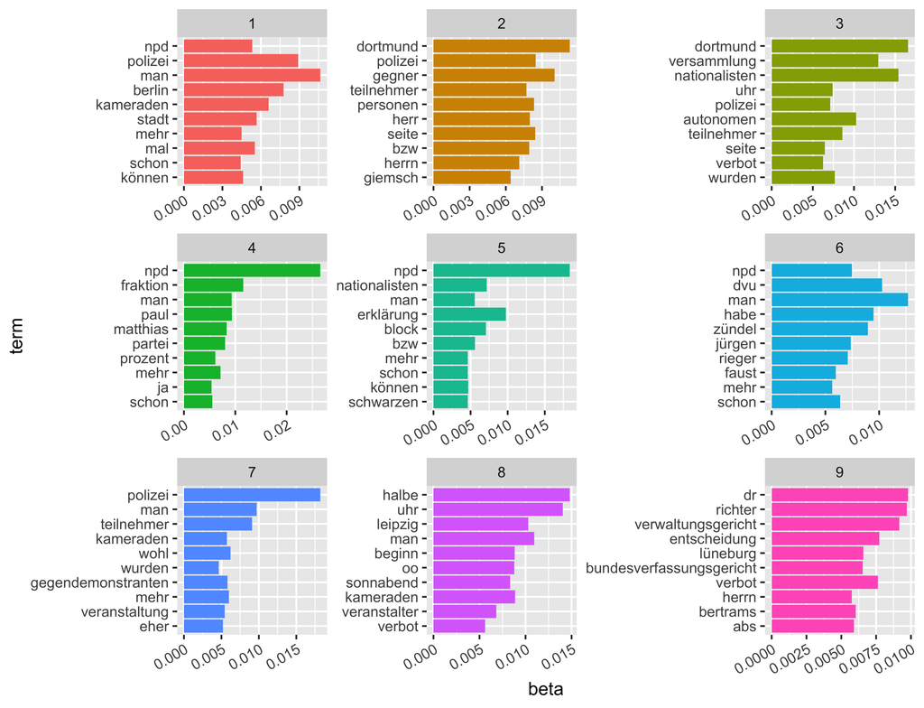

## FR leadership - Sellner topics

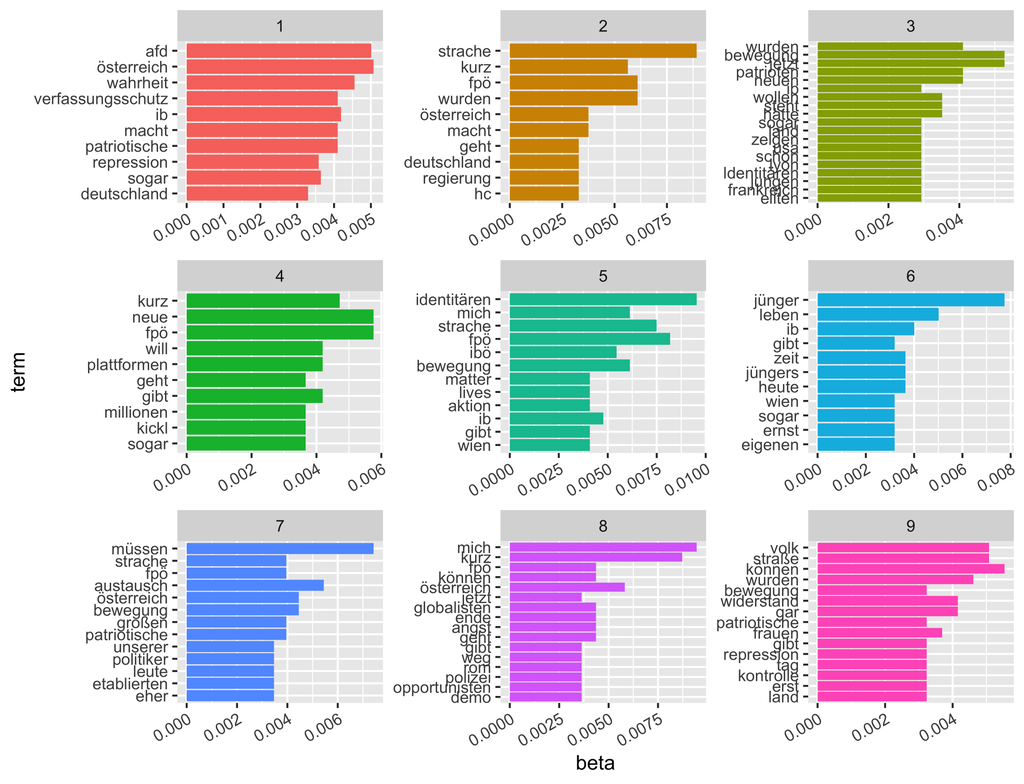

## FR leadership tasks

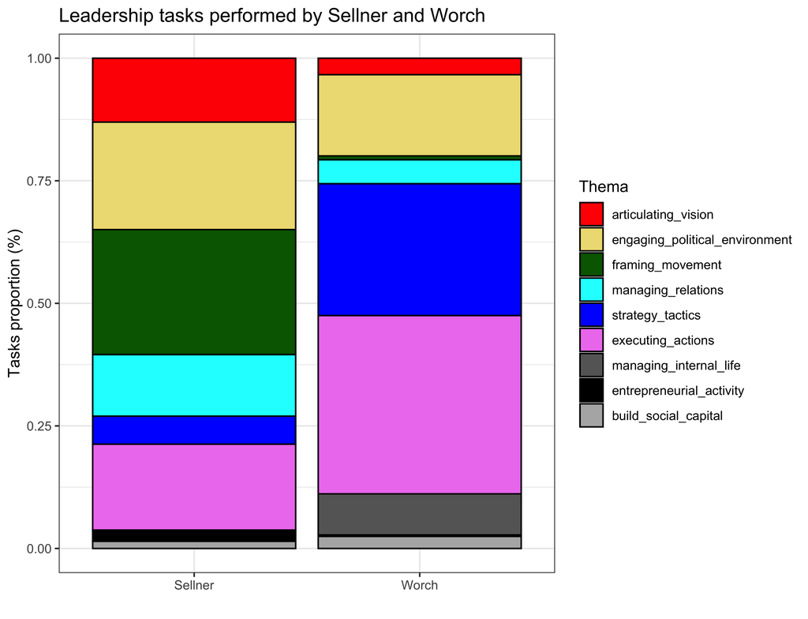

## FR leadership tasks by year

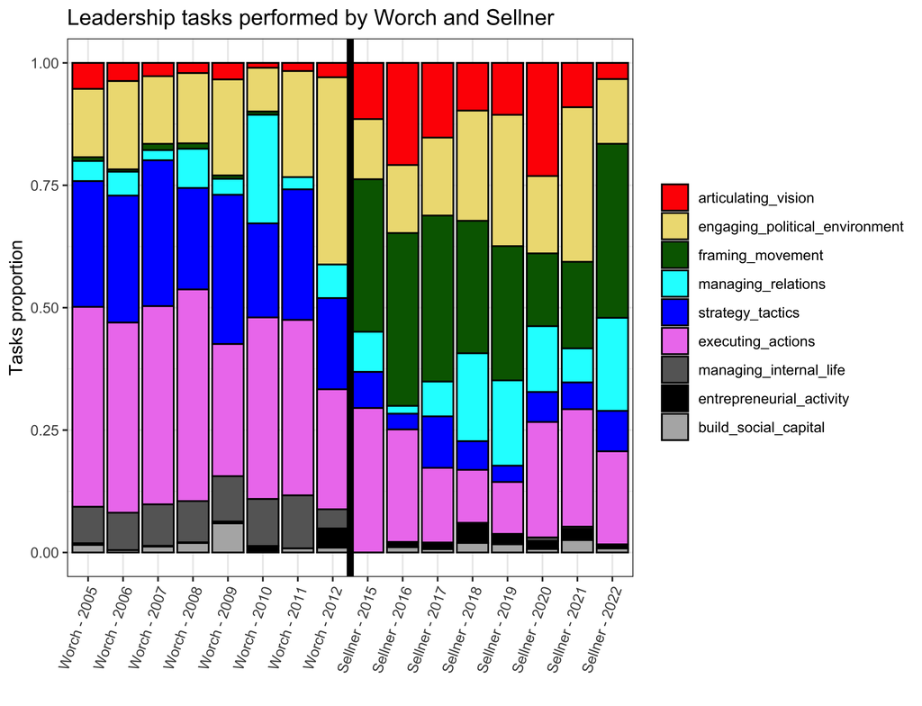

## FR leadership - conclusions

- Shared belief in street politics
  - social media are new tools—but both Worch and Sellner believe in change through mobilisation
  - mirroring left-wing tactics (imitation): IB as ‘right-wing clone’ of leftist movement organisations (at least according to Sellner); Worch’s *autonome Nationalisten*
- But Sellner is broader in his scope of activism, transnational if not global outlook
- Sellner more ideological: articulating vision and framing the movmement, `metapolitik’ (e.g., ‘Defend Europa’ cruise)
- Worch more practical: strategy and tactics and executing actions, emphasis on demonstrations and courts—punishing cities (e.g., Leipzig)

FYI: intro lecture on QTA: https://www.youtube.com/watch?v=bvqur70ZmyM

# Poll: leadership

[figure not shown]

Take the survey at **https://forms.gle/QxENrdB3qNpT1jSa8**

- militants more shaped by leaders than ‘ideologies’?
- *charismatic* leaders more likely to lead to violence?
- more horizontally organised groups less likely to be violent?
- leaders responsible/liable for violence of their followers?
- incitement through rhetoric similar to explicit orders?
- leaders’ ability to control ongoing violence overstated?

Questions about groups: (1) Did the group rely on centralised leadership? (2) Is group leadership based on formal hierarchy (i.e., not informal influence or reputation)? (3) Is the group’s network resilient to arrests or leadership loss? (4) How would you describe the group’s organisation?

[interactive chart not shown]

Militant movements are more shaped by their leaders than by their ideologies.

[interactive chart not shown]

## Poll results

Charismatic leadership more likely to lead to political violence

[interactive chart not shown]

Groups that reject hierarchical leadership are less likely to become violent

[interactive chart not shown]

## Poll results

Leaders should be held criminally responsible for the violent acts committed by their followers

[interactive chart not shown]

Leaders who rhetorically incite violence should be prosecuted like those who give orders

[interactive chart not shown]

## Poll results

Once violence has begun, a leader’s ability to control it is often overstated.

[interactive chart not shown]

## Open data - Networks of American Radicals (SoNAR)

- 2020s Network
- Centrality vis.
- Explanatory note

[interactive chart not shown]

This visualisation uses data from the Social Networks of American Radicals (SoNAR) project, which maps relationships among extremist offenders in the United States. The network visualisation shows network connections among radicals in the 2020s. The bar chart compares average network centrality across ideological milieus and illustrates differences in the structural positions occupied by actors within extremist networks. Network centrality provides an indication of how connected individuals are within a broader organisational environment and offers insight into patterns of influence, coordination, and leadership.

**National Consortium for the Study of Terrorism and Responses to Terrorism (START), University of Maryland. (2024). Profiles of Individual Radicalization in the United States (PIRUS) [Data file]. Retrieved from http://www.start.umd.edu/data-tools/profiles-individual-radicalization-united-states-pirus. Copyright University of Maryland 2024.**

## Open data - Provisional IRA, 1969-1998

- 1969–1976
- 1977–1980
- 1981–1989
- 1990–1998
- post-1998
- Note

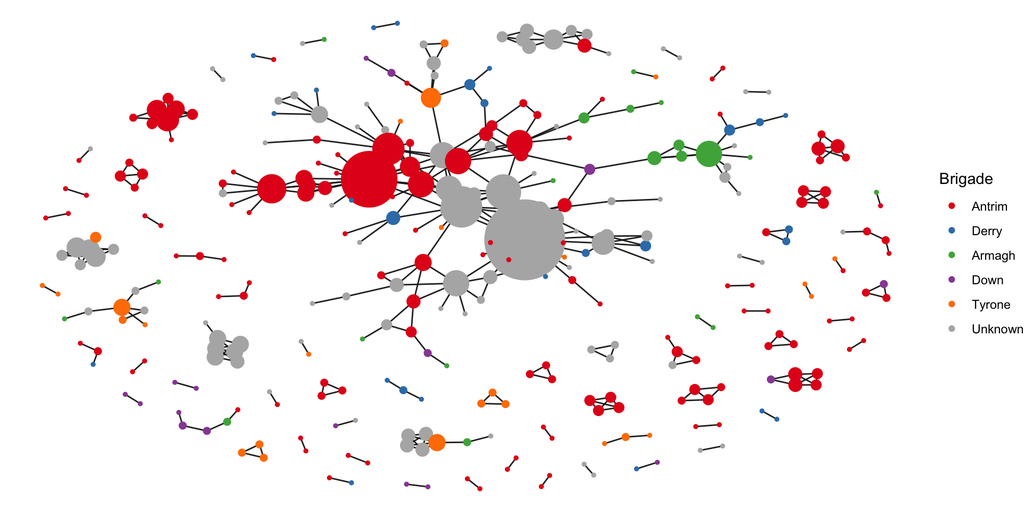

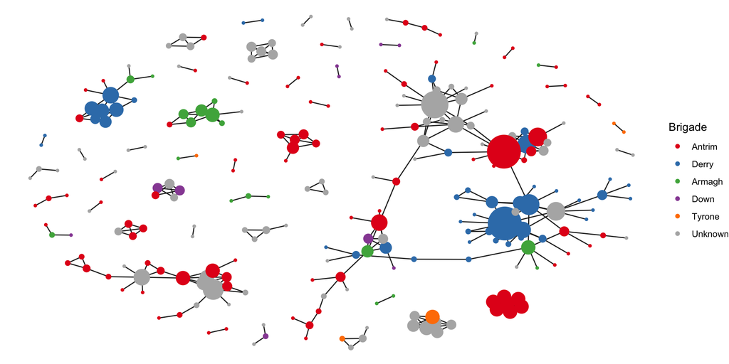

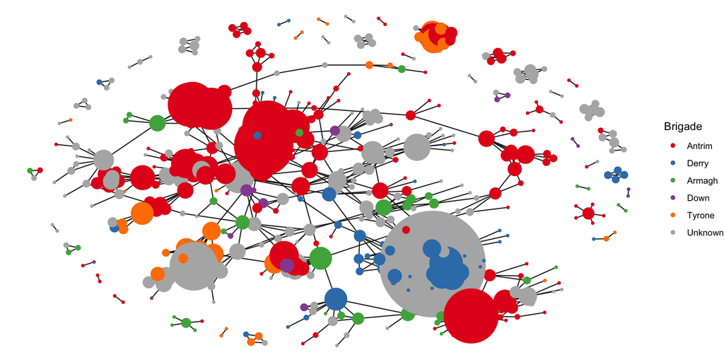

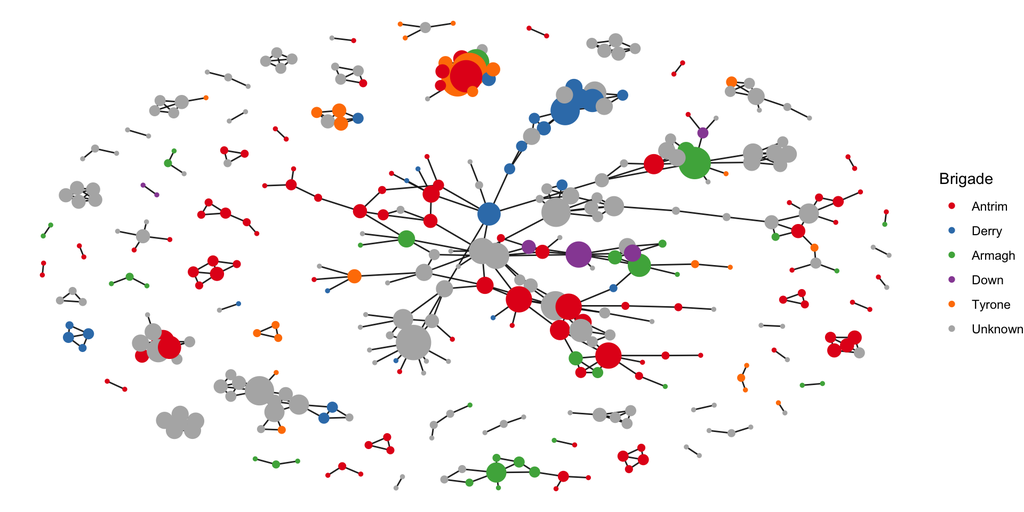

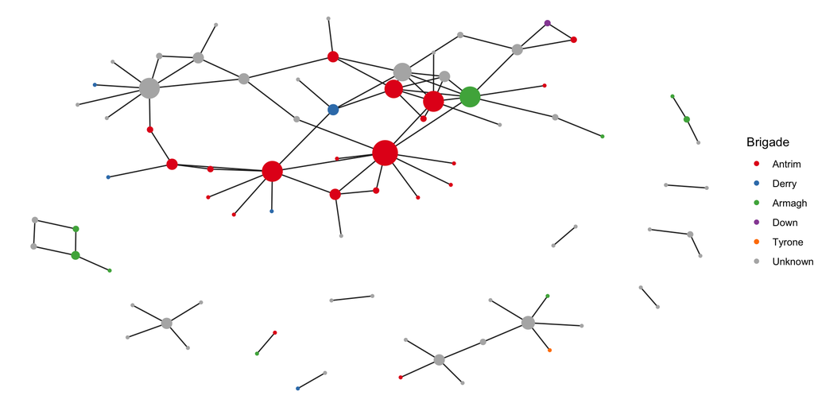

This visualisation is of data on active Provisional IRA (hereafter PIRA) members between 1970 and 1998, collected by the International Center for the Study of Terrorism, Pennsylvania State University, and [archived](https://sites.google.com/site/ucinetsoftware/datasets/covert-networks/provisional-irish-republican-army) by The University of Manchester’s [Mitchell Centre for Social Network Analysis](https://www.humanities.manchester.ac.uk/research/centres-institutes/mitchell-centre/research/past-projects/covert-networks/outputs/).

Originally published in: Gill, P., Lee, J., Rethemeyer, K. R., Horgan, J., & Asal, V. (2014). [Lethal connections: The determinants of network connections in the Provisional Irish Republican Army, 1970–1998](https://doi.org/10.1080/03050629.2013.863190). *International Interactions, 40*(1), 52-78.

# Research closer look

- Choi (2022) - Leader Nationalism, Ethnic Identity, and Terrorist Violence
  - key concept - *terrorism*
  - research design
  - results and findings
- Metodieva (2021) - The Radical Milieu and Radical Influencers of Bosnian Foreign Fighters
  - concepts, research design
  - results and findings

[Closer Look GIF](https://tenor.com/view/closer-look-gif-19341620)from [Closer GIFs](https://tenor.com/search/closer-gifs)

## Key concept (Choi 2022)

**Terrorism** - ‘the threatened or actual use of illegal force, directed against civilian targets, by nonstate actors, in order to attain a political goal, through fear, coercion or intimidation’ (LaFree and Ackerman 2009, 348).

## Research design (Choi 2022, 1153)

**Ooof! – what do we take from this?**

> Since the dependent variable is the count of terrorist incidents carried out by related ethnic groups per country-year, I consider a Poisson regression model as the estimation technique. But I find the Pearson goodness-of-fit $x^2$ test to be statistically significant ($x^2$ = 1,842,103, p< 0.001). This suggests that a Poisson regression estimation fails to fit the data correctly. I instead use multilevel mixed-effects negative binomial regression as an alternative estimation method. Because negative binomial regression adds a dispersion parameter to model the unobserved heterogeneity among observations, it can control for the overdispersion found in a Poisson regression model (Hilbe 2007). In addition, given the clustered nature of the data, with ethnic groups nested within year nested within country, I employ a multilevel mixed-effects negative binomial regression in which the ethnic groups comprise the first level, the years comprise the second level, and the countries comprise the third. In doing so, I assume that observations in the same cluster are correlated because they share common-level random effects.

## Research design (Choi 2022, 1153)

> Since the **dependent variable is the count** [initial technique selection criterion] of terrorist incidents carried out by related ethnic groups per country-year, I consider a Poisson regression model as the estimation technique. But I find the Pearson goodness-of-fit $x^2$ test to be statistically significant ($x^2$ = 1,842,103, p< 0.001) [technique diagnostic tool]. This suggests that a **Poisson regression estimation fails to fit the data correctly** [technique reselection]. I instead use multilevel mixed-effects negative binomial regression as an alternative estimation method. Because negative binomial regression **adds a dispersion parameter to model the unobserved heterogeneity among observations, it can control for the overdispersion found in a Poisson regression model** [technical adjustment] (Hilbe 2007). In addition, given the **clustered nature of the data**, with ethnic groups nested within year nested within country, I employ a multilevel mixed-effects negative binomial regression in which the ethnic groups comprise the first level, the years comprise the second level, and the countries comprise the third. In doing so, I assume that observations in the same cluster are correlated because they share common-level random effects.

## Research design (Choi 2022, 1153)

- sample of 766 ethnic groups from 163 countries during the period from 1970 to 2009
- sample data structured by ethnic group and year-country
  - unit of analysis is **group-year-country**
- terrorist attacks executed by ethnic groups in response to nationalist leaders
  - DV: *Ethnic Terrorism* - the total number of terrorist attacks carried out by related ethnic groups per year
- multilevel mixed-effects negative binomial regression analysis
  - multilevel: hierarchic data structure
  - mixed-effects: typically, *fixed* and *random* effects
    - **fixed**: estimation of regression coefficients of the covariates
    - **random**: used to estimate the effect of individual-specific characteristics that are typically unmeasurable
  - negative binomial regression: usually for over-dispersed count outcome variables

## Reading a regression table

Remember: regression is a tool for understanding a phenomenon as a linear function (generally) → (y = mx + b)

1. Numbers not in parentheses next to a variable: **regression coefficient**: expected change in DV for a one-unit increase in IV. NB: ositive or negative relationship?
2. Numbers inside parentheses next to a variable: **standard error**: estimate of the standard deviation of the coefficient
3. Asterisks/‘stars’: **statistical significance**: probability of results as extreme as observed result, under the assumption that the null hypothesis is correct. Smaller p-value means such an observation would be less likely under null hypothesis; hence, significance. Statistical significance suggests more precise estimates—NOT necessarily that one IV is more important than another.

## Regression results (Choi 2022, 1153)

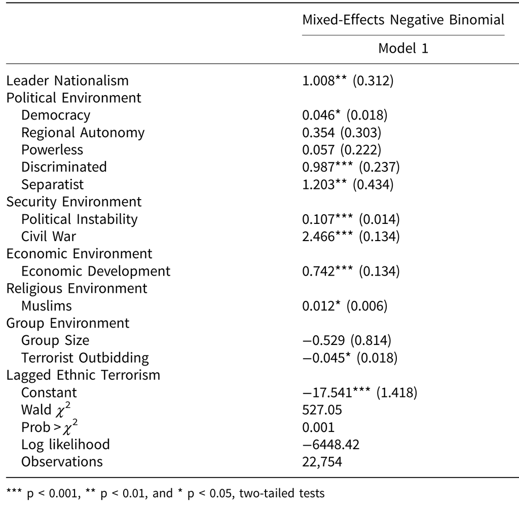

## Plotting average marginal effects (AME) (Choi 2022, 1153)

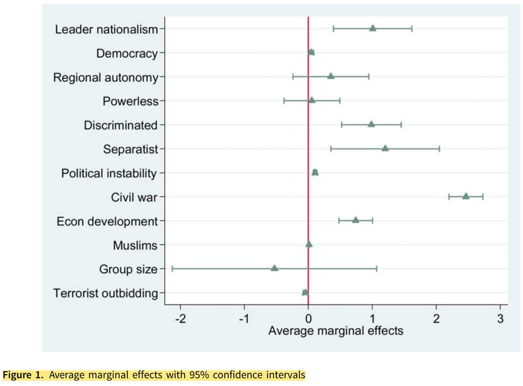

## Sri Lanka: Sinhalese-LTTE case (Choi 2022, 1153)

- 1948: Dudley Senanayake approves Ceylon Citizenship Act, denies citizenship to ‘migrant workers’ (incl. Tamils)
- 1956: Prime Minister Solomon Bandaranaike, Sinhalese nationalist and elevation of Buddhist myths and rituals
  - Sinhala Only Act, recognizing Sinhala as only official language of government
  - discrimination against, torture, murder of Tamils
- LTTE forms in 1976, major mobilisation in 1983
  - terrorist attacks, including assassinations, e.g., President Ranasinghe Premadasa in 1993.
  - case is consistent with large-N finding: leader nationalism precipitates ethnic terrorism

## Findings (Choi 2022, 1153)

- hardline nationalist leaders $\rightarrow$ more likely to provoke violence from disfavoured ethnic groups
- Political environment matters (remember concept from last class: **opportunity structure**). Democracy allows “disfavored ethnic groups to exploit the opportunities of political institutions such as freedom of association and freedom of the press to garner support for terrorist activity.” (cf. Jenne 2007)

## Concepts (Metodieva 2021)

- **radical milieu** - conducive environments for radicalisation, recruitment, and eventual engagement in violent extremism (Vidra and Zeller 2022) (a *family resemblance* concept, many different types and manifestations)
- **parajamaats** - illegal praying congregations (‘parallel mosque’)
- **power centres** - hotspots of radical activism, centred on influencers, who pushed followers to become foreign fighters
- **radical influencers** - prominent, often charismatic individuals capable of attracting followers
  - various functions: e.g., *ruqya* (spiritual healing)
  - parallels to cases you know of?
- **foreign fighters** - indiviuals who travel to a conflict zone from another territory (prima facie evidence of radicalism $\rightarrow$ *engagement* in political violence; a ‘security failure’ by authority of origin state?)

## Structures around radical influencers (Metodieva 2021)

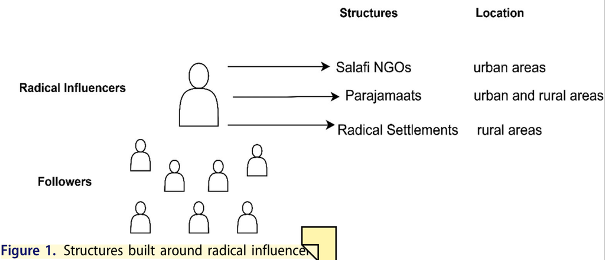

## Balkans particularly important for IS (Metodieva 2021)

three reasons:

1. linked to large diaspora communities in western Europe
2. societies with historical ties to Islam
3. region is marked by recent wars, and thus also by frozen but unresolved political and ethnic disputes

## Research design (Metodieva 2021)

- aim: “in what way leadership networks and authority affect how recruitment is done at the local level”; two claims
  1. wartime fuelled the growth of the Salafist movement in BiH (**creation and maintenance of radical milieu**–context! structure!)
  2. radical influencers who emerged had an ideological and organizational impact on the foreign fighter recruitment (**meso –> micro level recruitment processes**—agency!)
- case-based research: 11 radical influencers
  - purposive selection: *advocated violence* (17 nonviolent cases)
    - selecting on the DV (a no-no in inferential statistics—often desirable in case-based research where explaining outcomes [**not ‘explaining variation’**] is the objective)

## Data

- biographical data for 28 Salafi influencers
  - selected based on their (prominent) radical activism (videos, sermons, organising events)
  - 8 categorical variables: (1) influencer’s place of origin, (2) role in the radical milieu, (3) promotion/non-promotion of violence, (4) online and offline activism, (5) background in religious studies, (6) participation in the Bosnian War, (7) power center of influence, and (8) current status
- issues here? omissions?

## Data

- biographical data for 28 Salafi influencers
  - selected based on their (prominent) radical activism (videos, sermons, organising events)
  - 8 categorical variables: (1) influencer’s place of origin, (2) role in the radical milieu, (3) promotion/non-promotion of violence, (4) online and offline activism, (5) background in religious studies, (6) participation in the Bosnian War, (7) power center of influence, and (8) current status
- issues here? omissions?
  - good data collection practices (collect more than needed)
  - perhaps not ideal conceptualisation/measurement procedure
    1. background concept $\rightarrow$ 2. systematised concept $\rightarrow$ 3. indicators $\rightarrow$ 4. scoring cases (Adcock and Collier 2001)

## Power centres of fighter recruitment (Metodieva 2021)

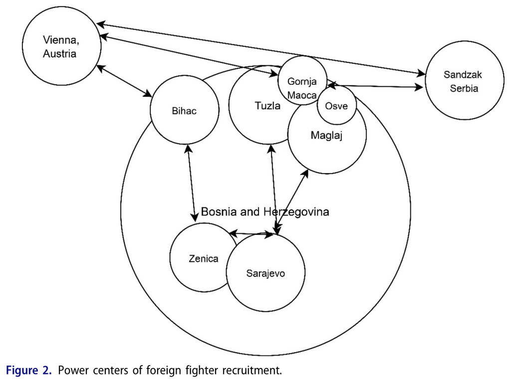

## Profiles of key influencers (Metodieva 2021, 13)

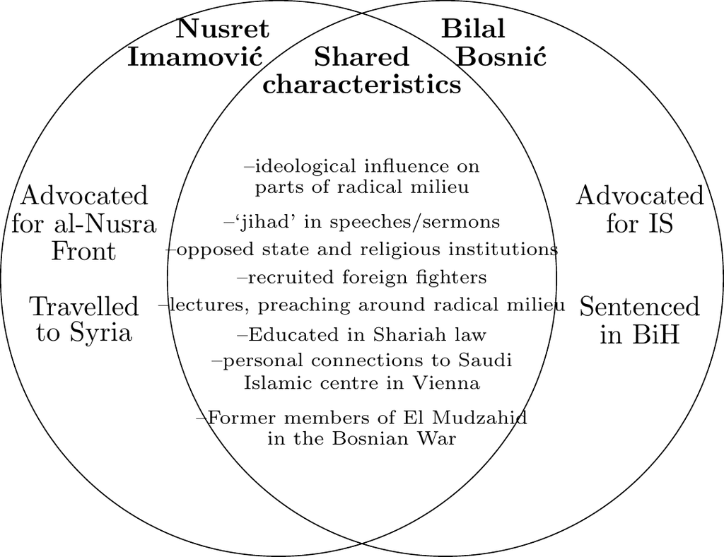

## Conclusion (Metodieva 2021, 17)

> Radical influencers may have **different pathways** and histories across cases of foreign fighter recruitment. They may vary in the resources they rely on. **In the postwar context of BiH, radical influencers shape** the recruitment of foreign fighters by managing preexisting “institutions” of the radical milieu. Influencers may fill a variety of power gaps and thus be able to access and target their followers. The reference to influencers instead of “recruiters” or “radical imams”, points to the finding that radical authority figures may have both ideological and (sometimes) operational functions in recruitment. Although they may lack strategic links to the centralized leadership of a terror organization, they have the power to influence the “bottom,” where prospective foreign fighters are situated.

## Group responses - leadership

group relies on centralised leadership

[interactive chart not shown]

Leadership based on formal hierarchy?

[interactive chart not shown]

## Group responses - org structure

group’s network is resilient to arrests or leadership loss

[interactive chart not shown]

## Group responses - org structure

group’s organisation is best described as…

[interactive chart not shown]

# Any questions, concerns, feedback for this class?

Anonymous feedback here: https://forms.gle/NfF1pCfYMbkAT3WP6

Alternatively, please send me an email: m.zeller@lmu.de

Questions about groups next meeting: (1) Did the group emerge in response to political repression? (2) Did the absence of (opportunity for) peaceful political participation contribute to the group’s use of violence? (3) Did the group actively recruit members from outside its primary country of operation? (4) How important were cross-border networks to this group’s activities? (5) Was the group’s cause was framed as an international struggle?

## References

Jenne, E. K. (2007). *Ethnic bargaining: The paradox of minority empowerment*. Cornell University Press.

McDonnell, D. (2016.) “Populist Leaders and Coterie Charisma.” *Political Studies 64*(3): 719-733.

Weber, M. (1922). *Wirtschaft und Gesellschaft: Grundriss der verstehenden Soziologie*. Tübingen: Mohr

Adcock, Robert, and David Collier. 2001. “Measurement Validity: A Shared Standard for Qualitative and Quantitative Research.” *American Political Science Review* 95 (3): 529–46. https://doi.org/10.1017/S0003055401003100.

Bourdieu, Pierre. 1986. “The Forms of Capital.” In *Handbook of Theory and Research in Sociology of Education*, edited by John G Richardson, 241–58. New York: Greenwald Press.

Busher, Joel, Gareth Harris, and Graham Macklin. 2018. “Chicken Suits and Other Aspects of Situated Credibility Contests: Explaining Local Trajectories of Anti-Minority Activism.” *Social Movement Studies* 18 (2): 193–214. https://doi.org/10.1080/14742837.2018.1530978.

Choi, Seung-Whan. 2022. “Leader Nationalism, Ethnic Identity, and Terrorist Violence.” *British Journal of Political Science* 52 (3): 1151–67. https://doi.org/10.1017/S0007123421000144.

Cleland, Jamie. 2020. “Charismatic Leadership in a Far-Right Movement: An Analysis of an English Defence League Message Board Following the Resignation of Tommy Robinson.” *Social Identities* 26 (1): 48–60.

Earl, Jennifer. 2007. “Leaderless Movement The Case of Strategic Voting.” *American Behavioral Scientist* 50 (10): 1327–49.

Macklin, Graham. 2020. *Failed Führers: A History of Britain’s Extreme Right*. Abingdon: Routledge.

Metodieva, Asya. 2021. “The Radical Milieu and Radical Influencers of Bosnian Foreign Fighters.” *Studies in Conflict & Terrorism* 0 (0): 1–21. https://doi.org/10.1080/1057610X.2020.1868097.

Nepstad, Sharon Erickson, and Clifford Bob. 2006. “When Do Leaders Matter? Hypotheses on Leadership Dynamics in Social Movements.” *Mobilization* 11 (1): 1–22. https://doi.org/10.17813/maiq.11.1.013313600164m727.

Vidra, Zsuzsanna, and Michael C Zeller. 2022. “Preventing Violent Extremism: A Delicate Balance.” Firenze: European University Institute: Robert Schuman Centre.

Virchow, Fabian. 2013. “Führer Und Schlüsselfiguren in Extrem Rechten Bewegungen.” *Forschungsjournal Soziale Bewegungen* 26 (4): 52–58.

Zeller, Michael C, and Fabian Virchow. 2024. “Far-Right Leadership in Comparison: Shifts and Continuities in German-speaking Movements.” *Social Movement Studies* 0 (0): 1–23. https://doi.org/10.1080/14742837.2024.2430974.